# Predictive model for house price in King County

Yuehao Xu, Carl Xu

yuehaox2

Abstract

## Introduction

In the history of human being, house have been the most important needs for human daily life. It is a place to keep our ancestors safe from wild animals. Today, it is a place that we can spend time with the whole family. In today’s world, our first concern after graduating from college is whether we can buy a house to raise the family. That’s the main reason most of people working so hard to make money. Now, I have a house sales dataset from Kaggle, which is is a platform for predictive modelling and analytics competitions. This dataset includes large amount of observations (about 21000) about the price of houses have been sold with about 20 features. This report is going to be building a model for predicting the house price based on the different feature. This report and the model have been created are useful insight for those who are thinking about buy a house in King County. People all have their desire features for their future home, but they do not know about the suitable price for it. Whenever you are under this situation, this report bring into play, which give you insight of affecting the price of house in king county. Below are some Exploratory Data Analysis about this dataset.

### Load Packages

- This part are essentially loading the packages we need to use in this report.

```r
library(caret)
library(kableExtra)
library(lattice)
library(ggplot2)
library(gridExtra)
library(glmnet)
library(car)
library(knitr)
```

### First look on data.

- This part we loading the data and apply several methods to have insights on our data.

```r
house = read.csv("https://daviddalpiaz.github.io/stat432sp18/projects/kc_house_data.csv")
str(house)
```

```
## 'data.frame':    21613 obs. of  21 variables:
##  $ id           : num  7.13e+09 6.41e+09 5.63e+09 2.49e+09 1.95e+09 ...
##  $ date         : Factor w/ 372 levels "20140502T000000",..: 165 221 291 221 284 11 57 252 340 306 ...
##  $ price        : num  221900 538000 180000 604000 510000 ...
##  $ bedrooms     : int  3 3 2 4 3 4 3 3 3 3 ...
##  $ bathrooms    : num  1 2.25 1 3 2 4.5 2.25 1.5 1 2.5 ...
##  $ sqft_living  : int  1180 2570 770 1960 1680 5420 1715 1060 1780 1890 ...
##  $ sqft_lot     : int  5650 7242 10000 5000 8080 101930 6819 9711 7470 6560 ...
##  $ floors       : num  1 2 1 1 1 1 2 1 1 2 ...
##  $ waterfront   : int  0 0 0 0 0 0 0 0 0 0 ...
##  $ view         : int  0 0 0 0 0 0 0 0 0 0 ...
##  $ condition    : int  3 3 3 5 3 3 3 3 3 3 ...
##  $ grade        : int  7 7 6 7 8 11 7 7 7 7 ...
##  $ sqft_above   : int  1180 2170 770 1050 1680 3890 1715 1060 1050 1890 ...
##  $ sqft_basement: int  0 400 0 910 0 1530 0 0 730 0 ...
##  $ yr_built     : int  1955 1951 1933 1965 1987 2001 1995 1963 1960 2003 ...
##  $ yr_renovated : int  0 1991 0 0 0 0 0 0 0 0 ...
##  $ zipcode      : int  98178 98125 98028 98136 98074 98053 98003 98198 98146 98038 ...
##  $ lat          : num  47.5 47.7 47.7 47.5 47.6 ...
##  $ long         : num  -122 -122 -122 -122 -122 ...
##  $ sqft_living15: int  1340 1690 2720 1360 1800 4760 2238 1650 1780 2390 ...
##  $ sqft_lot15   : int  5650 7639 8062 5000 7503 101930 6819 9711 8113 7570 ...
```

- From the summary above, we have a idea on what does the data includes. By intuition, if we want to predict price from other feature. There are some features are useless predicting price (Id, date, zipcode, lat, long, yr_renovated,yr_built). Also all the variable are coding as numeric variables. We may want to force some of these variable into factor (waterfront)

```r
useless = c("id", "date", "zipcode", "lat", "long", "yr_renovated","yr_built")

new_house = house[,! names(house) %in% useless, drop = F]

str(new_house)
```

```
## 'data.frame':    21613 obs. of  14 variables:
##  $ price        : num  221900 538000 180000 604000 510000 ...
##  $ bedrooms     : int  3 3 2 4 3 4 3 3 3 3 ...
##  $ bathrooms    : num  1 2.25 1 3 2 4.5 2.25 1.5 1 2.5 ...
##  $ sqft_living  : int  1180 2570 770 1960 1680 5420 1715 1060 1780 1890 ...
##  $ sqft_lot     : int  5650 7242 10000 5000 8080 101930 6819 9711 7470 6560 ...
##  $ floors       : num  1 2 1 1 1 1 2 1 1 2 ...
##  $ waterfront   : int  0 0 0 0 0 0 0 0 0 0 ...
##  $ view         : int  0 0 0 0 0 0 0 0 0 0 ...
##  $ condition    : int  3 3 3 5 3 3 3 3 3 3 ...
##  $ grade        : int  7 7 6 7 8 11 7 7 7 7 ...
##  $ sqft_above   : int  1180 2170 770 1050 1680 3890 1715 1060 1050 1890 ...
##  $ sqft_basement: int  0 400 0 910 0 1530 0 0 730 0 ...
##  $ sqft_living15: int  1340 1690 2720 1360 1800 4760 2238 1650 1780 2390 ...
##  $ sqft_lot15   : int  5650 7639 8062 5000 7503 101930 6819 9711 8113 7570 ...
```

- Now, the new dataset is being revised, and it is suitable to build model.
- From the summary of this dataset. We can see that the lowest price is 75000, and the highest is 7700000. There is a huge range of the price variable. We might want to know what are the factor have impact on the price. Also the minimum number of bedroom and bathroom is 0, this draw my attention. It is kind of werid.

### Checking data if it needs to be cleaned.

```r
sapply(new_house, function(x) sum(is.na(x)))
```

```
##         price      bedrooms     bathrooms   sqft_living      sqft_lot
##             0             0             0             0             0
##        floors    waterfront          view     condition         grade
##             0             0             0             0             0
##    sqft_above sqft_basement sqft_living15    sqft_lot15
##             0             0             0             0
```

- As we can see, there is no missing value in the dataset.

### Visualize the data

- Since our goal is to make a model that predict the price of house. We should probably need to see how price is distributed.

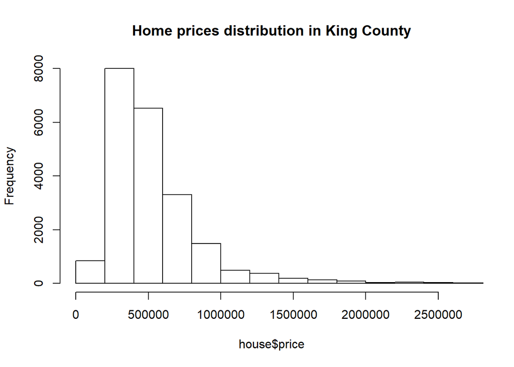

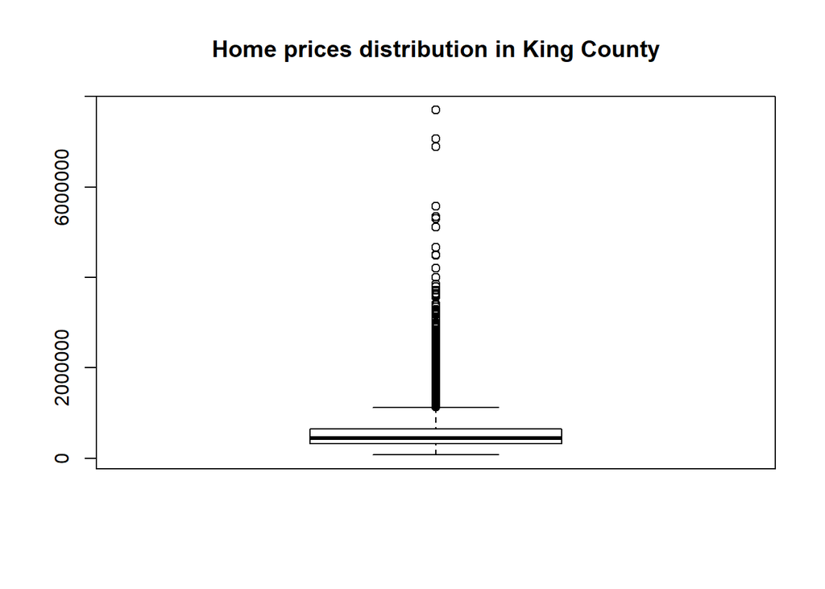

- From the plot, we can see that most of house prices are around 500,000. From the boxplot we can tell that there are some extreme values in the dataset, but most of them are below 2000,000.

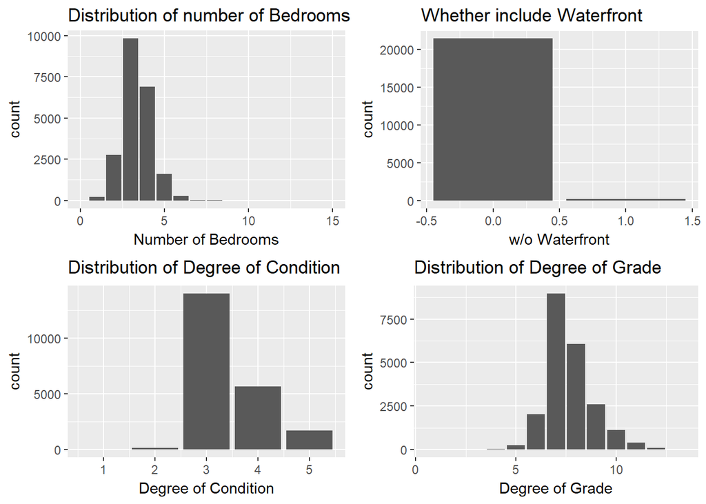

- From the distribution plots, we can see that the number of houses with 3 bedrooms are the most. And the number of houses with medium condition(3) are the most among all level of conditions. The number of houses with medium grade(7) are the most among all level of grades. Most of house does not have waterfront.

## Method

> In this report, I will be buidling `Linear regression model` and `scaled k nearest neighbor model` and `unscaled k nearest neighbor model`. Compare those models and pick one best model out of it based on the Root Mean Sqaure Error.

### Split Data

> This part is aim to split the data into train set and test set. Training data is used for train the model, here I randomly choose 80% of data as our training set. Test set is for the validation of our models. The RMSE of test set would be our guideline to pick model. The lowest the better.

```r
set.seed(654447675)
house_trn_idx  = sample(nrow(new_house), size = trunc(0.80 * nrow(new_house)))
house_trn_data = new_house[house_trn_idx, ]
house_tst_data = new_house[-house_trn_idx, ]
```

### Variable Selection by Ridge Regression

> We are relatively large amount of predictors, we may want to apply ridge regression to perform variable selection. With many predictors, fitting the full model without penalization will result in large prediction intervals. Ridge regression puts further constraints on the parameters, in the linear model.

```r
X = model.matrix(price ~ ., house_trn_data)[, -1]
y = house_trn_data$price
fit_ridge_cv = cv.glmnet(X, y, alpha = 0)
coef(fit_ridge_cv, s = "lambda.1se")
```

```
## 14 x 1 sparse Matrix of class "dgCMatrix"
##                              1
## (Intercept)   -498885.76359957
## bedrooms       -11643.67756063
## bathrooms       21992.76898399
## sqft_living        71.41079510
## sqft_lot           -0.02625423
## floors           7678.94835726
## waterfront     466861.68103855
## view            56210.99072699
## condition       37875.21076716
## grade           64433.73998491
## sqft_above         63.42815053
## sqft_basement      86.40723138
## sqft_living15      49.29469985
## sqft_lot15         -0.33262659
```

- While we are using the ridge regression, we can see that ridge regression try to minimize the effect of “sqft_lot”,“sqft_living”,“sqft_above”,“sqft_basement”,“sqft_living15”,“sqft_lot15”, we might consider delete these variables and keep other variables in the data.

```r
not_use = c("sqft_lot","sqft_living","sqft_above","sqft_basement","sqft_living15","sqft_lot15")
house_trn_data = house_trn_data[,! names(house_trn_data) %in% not_use, drop = F]
house_tst_data = house_tst_data[,! names(house_tst_data) %in% not_use, drop = F]
```

- After we have new selected train and test dataset We can train the model with it.

**Description of Variables keeps in the dataset are in the `Appendix part`**

### Train Linear Model

```r
set.seed(12)

house_lm_mod = train(
  price ~ .,
  data = house_trn_data,
  trControl = trainControl(method = "cv", number = 5),
  method = "lm"
)
```

- While I am training the model, I also applied 5 folds cross validation.

### Train unscaled KNN Model

```r
set.seed(12)
house_knn_mod = train(
  price ~.,
  data = house_trn_data,
  trControl = trainControl(method = "cv", number = 5),
  method = "knn",
  tuneGrid = expand.grid(k = c(1, 5, 10, 15, 20, 25, 30, 35, 40, 45, 50))
)
```

- While I am training the model, I also applied 5 folds cross validation with k = (1, 5, 10, 15, 20, 25, 30, 35, 40, 45, 50)

### Train scaled KNN model

```r
set.seed(12)
house_knn_mod_scale = train(
  price ~.,
  data = house_trn_data,
  trControl = trainControl(method = "cv", number = 5),
  preProcess = c("center", "scale"),
  method = "knn",
  tuneGrid = expand.grid(k = c(1, 5, 10, 15, 20, 25, 30, 35, 40, 45, 50))
)
```

- While I am training the model, I also applied 5 folds cross validation with k = (1, 5, 10, 15, 20, 25, 30, 35, 40, 45, 50)

### Plot of Error for scaled and non-scaled KNN Model

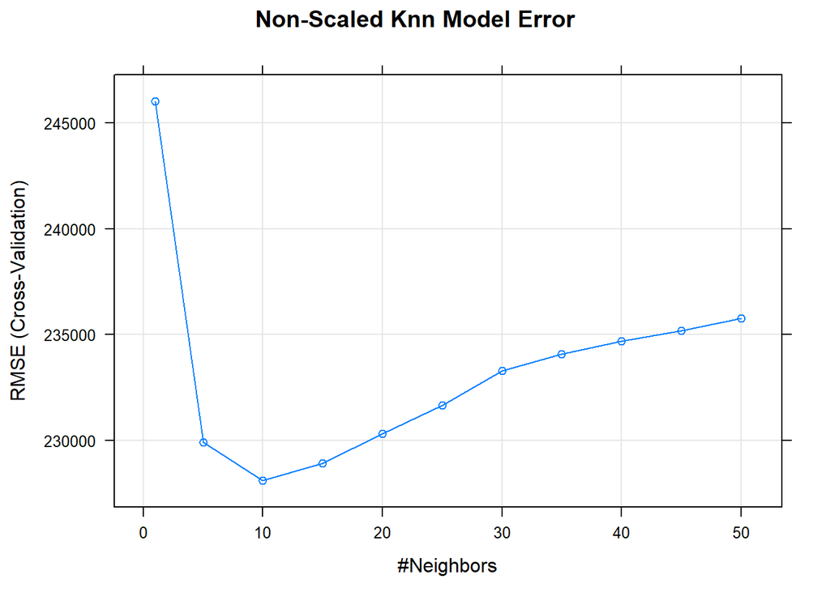

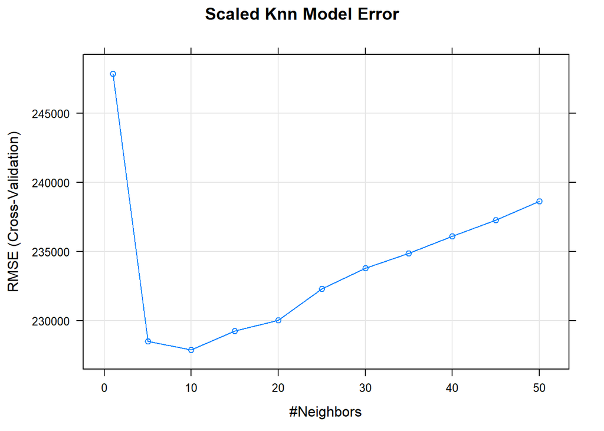

- From the plot above we can see that both KNN models perform best when k = 10 since they have the lowest error

### Functions calculating RMSE

> Below include two functions that facilitate us to calculate the RMSE for each model.

```r
calc_rmse = function(actual, predicted) {
  sqrt(mean((actual - predicted) ^ 2))
}

get_best_result = function(caret_fit) {
  best = which(rownames(caret_fit$results) == rownames(caret_fit$bestTune))
  best_result = caret_fit$results[best, ]
  rownames(best_result) = NULL
  best_result
}
```

## Result

### RMSE result table for models

| Method | Train RMSE | Test RMSE |
| --- | --- | --- |
| Linear Regression | 250364.1 | 235234.6 |
| KNN Unscaled | 228101.3 | 215987.1 |
| KNN Scaled | 227889.4 | 217514.3 |

```r
house_knn_mod_scale$bestTune
```

```
##    k
## 3 10
```

- In the scaled KNN model, when K = 10, this model perform the best.

## Discussion

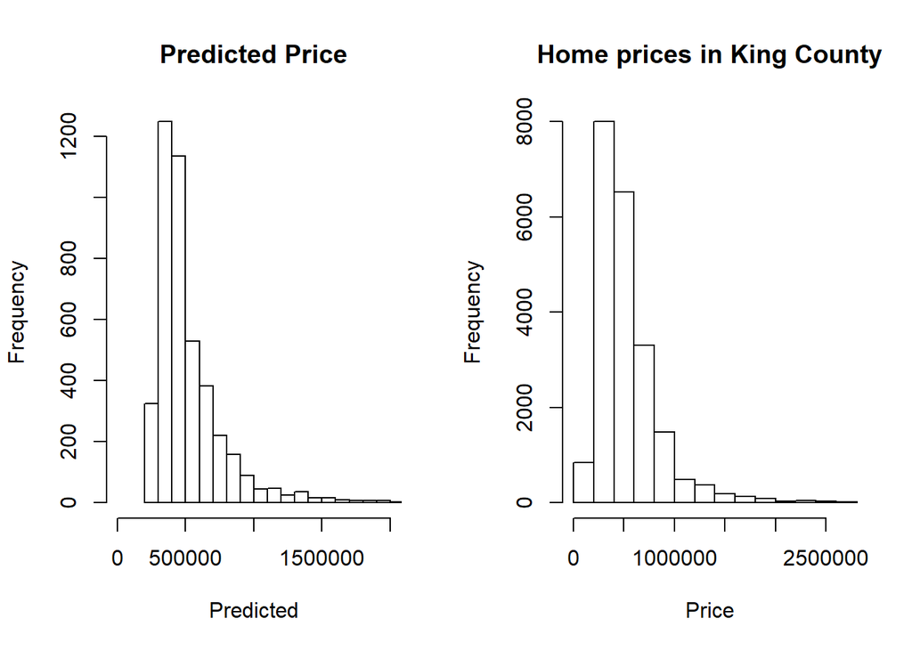

- The histogram above is the prediction result by using test dataset and the scaled knn model. We can tell that it is quite similar to the original price histogram we implement in the introduction part, which indicates this model are making some of good prediction.

```r
summary(predict(house_knn_mod_scale, newdata = house_tst_data))
```

```
##    Min. 1st Qu.  Median    Mean 3rd Qu.    Max.
##  210950  367547  455822  528520  600531 2787808
```

```r
summary(house$price)
```

```
##    Min. 1st Qu.  Median    Mean 3rd Qu.    Max.
##   75000  321950  450000  540088  645000 7700000
```

- Here are some statistics about the prediction values, which seems reasonable. And it is within a reasonable range. From the comparison of two set of statistics, we can tell that the mean and median are very close. However, in our original data set, the price is range from 75000 to 7700000. And the predicted value from my model is from 210950 to 2787808. From previous analysis, we know that most of price values in the original dataset are below the 2000000, others might treated as extreme values. And our knn model with k = 10 seems eliminate the effect of extreme value, which is reasonable because we take k = 10. If there is 1 extreme value, and the rest are normal values, which is 9/10. After we take the mean of these ten values, it brings the predicted price to normal values.
- But I think there is shortcoming predicting a really expensive house. In the introduction part, we see that the most number of bedrooms are 33, a house with 33 bedrooms must be super expensive. And our predicted value has maximum of 2787808, which might not suitable predicting those. We might consider further evaluation of models or building different model. For now, this model can be used to predict some medium price house, around 500000. And this number is kind of affordable for yound people if they are willing to take loans.

## Appendix

### Data Variables Description:

> This part describe the variables are used in the final model.

**price** - prediction target (numeric)

**bedrooms** - Number of Bedrooms (numeric)

**bathrooms** - Number of bathrooms (numeric)

**floors** - Total floors in house (numeric)

**waterfront** - House which has a view to a waterfront (categorical)

**view** - Has been viewed (numeric)

**condition** - How good the condition is (overall) (numeric)

**grade** - Overall grade given to the housing unit, based on King County grading system (numeric)

> This part describe the all variables in the data.

**id** - Notation for a house (numeric)

**date** - Date house was sold (numeric)

**sqft_living** - square footage of the home (numeric)

**sqft_lot** - square footage of the lot (numeric)

**sqft_above** - square footage of house apart from basement (numeric)

**sqft_basement** - square footage of the basement (numeric)

**yr_built** - Built Year (numeric)

**yr_renovated** - Year when house was renovated (numeric)

**zipcode** - zip (numeric)

**lat** - Latitude coordinate (numeric)

**long** - Longitude coordinate (numeric)

**sqft_living15** - Living room area in 2015(implies– some renovations)This might or might not have affected the lotsize area (numeric)

**sqft_lot15** - lotSize area in 2015(implies– some renovations) (numeric)

**price** - prediction target (numeric)

**bedrooms** - Number of Bedrooms (numeric)

**bathrooms** - Number of bathrooms (numeric)

**floors** - Total floors in house (numeric)

**waterfront** - House which has a view to a waterfront (categorical)

**view** - Has been viewed (numeric)

**condition** - How good the condition is (overall) (numeric)

**grade** - Overall grade given to the housing unit, based on King County grading system (numeric)

### Extra EDA

#### Data basic information

```r
head(house)
```

```
##           id            date   price bedrooms bathrooms sqft_living
## 1 7129300520 20141013T000000  221900        3      1.00        1180
## 2 6414100192 20141209T000000  538000        3      2.25        2570
## 3 5631500400 20150225T000000  180000        2      1.00         770
## 4 2487200875 20141209T000000  604000        4      3.00        1960
## 5 1954400510 20150218T000000  510000        3      2.00        1680
## 6 7237550310 20140512T000000 1225000        4      4.50        5420
##   sqft_lot floors waterfront view condition grade sqft_above sqft_basement
## 1     5650      1          0    0         3     7       1180             0
## 2     7242      2          0    0         3     7       2170           400
## 3    10000      1          0    0         3     6        770             0
## 4     5000      1          0    0         5     7       1050           910
## 5     8080      1          0    0         3     8       1680             0
## 6   101930      1          0    0         3    11       3890          1530
##   yr_built yr_renovated zipcode     lat     long sqft_living15 sqft_lot15
## 1     1955            0   98178 47.5112 -122.257          1340       5650
## 2     1951         1991   98125 47.7210 -122.319          1690       7639
## 3     1933            0   98028 47.7379 -122.233          2720       8062
## 4     1965            0   98136 47.5208 -122.393          1360       5000
## 5     1987            0   98074 47.6168 -122.045          1800       7503
## 6     2001            0   98053 47.6561 -122.005          4760     101930
```

```r
summary(house)
```

```
##        id                          date           price
##  Min.   :   1000102   20140623T000000:  142   Min.   :  75000
##  1st Qu.:2123049194   20140625T000000:  131   1st Qu.: 321950
##  Median :3904930410   20140626T000000:  131   Median : 450000
##  Mean   :4580301521   20140708T000000:  127   Mean   : 540088
##  3rd Qu.:7308900445   20150427T000000:  126   3rd Qu.: 645000
##  Max.   :9900000190   20150325T000000:  123   Max.   :7700000
##                       (Other)        :20833
##     bedrooms        bathrooms      sqft_living       sqft_lot
##  Min.   : 0.000   Min.   :0.000   Min.   :  290   Min.   :    520
##  1st Qu.: 3.000   1st Qu.:1.750   1st Qu.: 1427   1st Qu.:   5040
##  Median : 3.000   Median :2.250   Median : 1910   Median :   7618
##  Mean   : 3.371   Mean   :2.115   Mean   : 2080   Mean   :  15107
##  3rd Qu.: 4.000   3rd Qu.:2.500   3rd Qu.: 2550   3rd Qu.:  10688
##  Max.   :33.000   Max.   :8.000   Max.   :13540   Max.   :1651359
##
##      floors        waterfront            view          condition
##  Min.   :1.000   Min.   :0.000000   Min.   :0.0000   Min.   :1.000
##  1st Qu.:1.000   1st Qu.:0.000000   1st Qu.:0.0000   1st Qu.:3.000
##  Median :1.500   Median :0.000000   Median :0.0000   Median :3.000
##  Mean   :1.494   Mean   :0.007542   Mean   :0.2343   Mean   :3.409
##  3rd Qu.:2.000   3rd Qu.:0.000000   3rd Qu.:0.0000   3rd Qu.:4.000
##  Max.   :3.500   Max.   :1.000000   Max.   :4.0000   Max.   :5.000
##
##      grade          sqft_above   sqft_basement       yr_built
##  Min.   : 1.000   Min.   : 290   Min.   :   0.0   Min.   :1900
##  1st Qu.: 7.000   1st Qu.:1190   1st Qu.:   0.0   1st Qu.:1951
##  Median : 7.000   Median :1560   Median :   0.0   Median :1975
##  Mean   : 7.657   Mean   :1788   Mean   : 291.5   Mean   :1971
##  3rd Qu.: 8.000   3rd Qu.:2210   3rd Qu.: 560.0   3rd Qu.:1997
##  Max.   :13.000   Max.   :9410   Max.   :4820.0   Max.   :2015
##
##   yr_renovated       zipcode           lat             long
##  Min.   :   0.0   Min.   :98001   Min.   :47.16   Min.   :-122.5
##  1st Qu.:   0.0   1st Qu.:98033   1st Qu.:47.47   1st Qu.:-122.3
##  Median :   0.0   Median :98065   Median :47.57   Median :-122.2
##  Mean   :  84.4   Mean   :98078   Mean   :47.56   Mean   :-122.2
##  3rd Qu.:   0.0   3rd Qu.:98118   3rd Qu.:47.68   3rd Qu.:-122.1
##  Max.   :2015.0   Max.   :98199   Max.   :47.78   Max.   :-121.3
##
##  sqft_living15    sqft_lot15
##  Min.   : 399   Min.   :   651
##  1st Qu.:1490   1st Qu.:  5100
##  Median :1840   Median :  7620
##  Mean   :1987   Mean   : 12768
##  3rd Qu.:2360   3rd Qu.: 10083
##  Max.   :6210   Max.   :871200
##
```